# Simulations in R Part 7 - Measurement Error in Regression

Patrick Ward

10/1/2023

# Measurement Error

Measurement error occurs when the values we have observed during data collection differ from the true values. This can sometimes be the cause of imperfect proxy measures where we are using certain measurements (perhaps tests that are easier to obtain in our population or setting) in place of the thing we actually care about. Or, it can happen because tests are imperfect and all data collection has limitations and error (which we try as hard as possible to minimize).

Measurement error can be systematic or random. It can be challenging to detect in a single sample. We will build a simulation to show how measurement error can bias our regression coefficients and perhaps hide the true relationship.

# Constructing the simulation

For this simulation, we are going to use a random draw from a normal distribution for the independent variable to represent noise in the model, which will behave like measurement error. We will use a nested `for()` loop, as we did in `Part 6` of this series, where the outer loop stores the outcomes of the regression model under each level of measurement error, which is built in the inner loop.

```r
## load packages
library(tidyverse)
```

```r
theme_set(theme_minimal() +
          theme(axis.text = element_text(size = 15, face = "bold"),
                axis.title = element_text(size = 13, face = "bold"),
                plot.title = element_text(size = 18)))

## levels of error measurement to test
# NOTE: these values will be used as the standard deviation in our random draws
meas_error <- seq(from = 0, to = 1, by = 0.1)

# create the number of simulations and reps you want to run
n <- 1000

# true variables
intercept <- 2
beta1 <- 5
independent_var <- runif(n = n, min = -1, max = 1)

## create a final array store each of the model error levels in their own list
final_df <- array(data = NA, dim = c(n, 2, length(meas_error)))

## create a data frame to store the absolute bias at each level of measurement error
error_bias_df <- matrix(nrow = n, ncol = length(meas_error))

## loop
for(j in 1:length(meas_error)){

  # a store vector for the absolute bias from each inner loop
  abs_bias_vect <- rep(0, times = n)

  ## storage data frame for the beta coefficient results in each inner loop simulated regression
  df_betas <- matrix(NA, nrow = n, ncol = 2)

  # simulate independent variable 1000x with measurement error
  ind_var_with_error <- independent_var + rnorm(n = n, 0, meas_error[j])

  for(i in 1:n){

    y_hat <- intercept + beta1*independent_var + rnorm(n = n, 0, 1)
    fit <- lm(y_hat ~ ind_var_with_error)

    df_betas[i, 1] <- fit$coef[1]
    df_betas[i, 2] <- fit$coef[2]

    abs_bias_vect[i] <- abs(fit$coef[2] - beta1)
  }

  ## store final results of each inner loop
  # store the model betas in a list for each level of measurement error
  final_df[, , j] <- df_betas

  # store the absolute bias
  error_bias_df[, j] <- abs_bias_vect

}

## check the first few values of each new element
head(error_bias_df)
```

```
##            [,1]      [,2]      [,3]     [,4]     [,5]     [,6]     [,7]
## [1,] 0.02896864 0.2279709 0.7317098 1.107494 1.800680 2.116757 2.672949
## [2,] 0.12084101 0.2416451 0.7030892 1.093615 1.724747 2.111272 2.569099
## [3,] 0.07037168 0.1776686 0.5817435 1.062583 1.635120 2.213353 2.579674
## [4,] 0.09881386 0.1600963 0.6961947 1.046052 1.769624 2.156116 2.666358
## [5,] 0.09235057 0.2812247 0.5217806 1.074653 1.699279 2.204869 2.635830
## [6,] 0.13553493 0.2233934 0.7310330 1.024274 1.784236 2.238448 2.662997
##          [,8]     [,9]    [,10]    [,11]
## [1,] 3.053672 3.308772 3.532203 3.891328
## [2,] 3.048569 3.295290 3.598363 3.951722
## [3,] 3.062065 3.329858 3.566206 3.932016
## [4,] 3.055005 3.257412 3.581040 3.844847
## [5,] 3.078123 3.303130 3.601939 3.913935
## [6,] 3.050327 3.246986 3.553788 3.933328
```

```r
## the final_df's are stored as a list of arrays for each level of measurement error
# Here is the 11th array (measurement error == 1.0)
head(final_df[, ,11])
```

```
##          [,1]     [,2]
## [1,] 2.157748 1.108672
## [2,] 2.143392 1.048278
## [3,] 2.216178 1.067984
## [4,] 2.146387 1.155153
## [5,] 2.203125 1.086065
## [6,] 2.199262 1.066672
```

# Plotting the results

Now that we have stored the data for each level of measurement error, let’s do some plotting of the data to explore how measurement error influences our regression model.

**Plot the standard deviation of the beta coefficient for the model with no measurement error and the model with the most extreme measurement error**

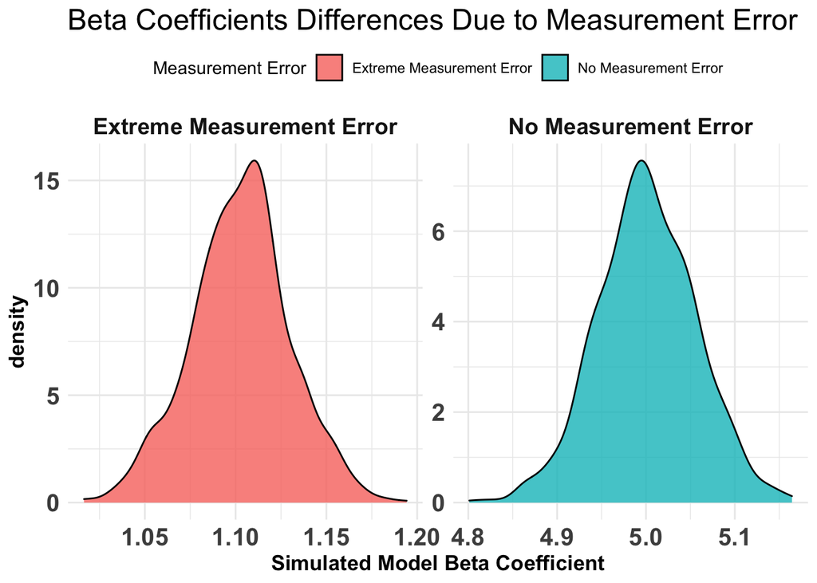

```r
no_error <- final_df[, ,1] %>% as.data.frame() %>% mutate(measurement_error = "No Measurement Error")

extreme_error <- final_df[, ,11] %>% as.data.frame() %>% mutate(measurement_error = "Extreme Measurement Error")

no_error %>%
  bind_rows(
    extreme_error
  ) %>%
  ggplot(aes(x = V2, fill = measurement_error)) +
  geom_density(alpha = 0.8) +
  facet_wrap(~measurement_error, scales = "free") +
  theme(strip.text = element_text(size = 14, face = "bold"),
        legend.position = "top") +
  labs(x = "Simulated Model Beta Coefficient",
       fill = "Measurement Error",
       title = "Beta Coefficients Differences Due to Measurement Error")
```

**Plot the change in absolute bias across each level of measurement error**

```r
absolute_error <- error_bias_df %>%
  as.data.frame() %>%
  setNames(paste0('x', meas_error))

# On average, how much absolute bias would we expect
colMeans(absolute_error) %>%
  data.frame() %>%
  rownames_to_column() %>%
  mutate('rowname' = parse_number(rowname)) %>%
  setNames(c("Level of measurement error", 'Absolute bias')) %>%
  gt::gt()
```

| Level of measurement error | Absolute bias |
| --- | --- |
| 0.0 | 0.0436500 |
| 0.1 | 0.1942778 |
| 0.2 | 0.6197878 |
| 0.3 | 1.0862904 |
| 0.4 | 1.7760042 |
| 0.5 | 2.1845748 |
| 0.6 | 2.6476613 |
| 0.7 | 3.0666906 |
| 0.8 | 3.2832416 |
| 0.9 | 3.5718880 |
| 1.0 | 3.8973500 |

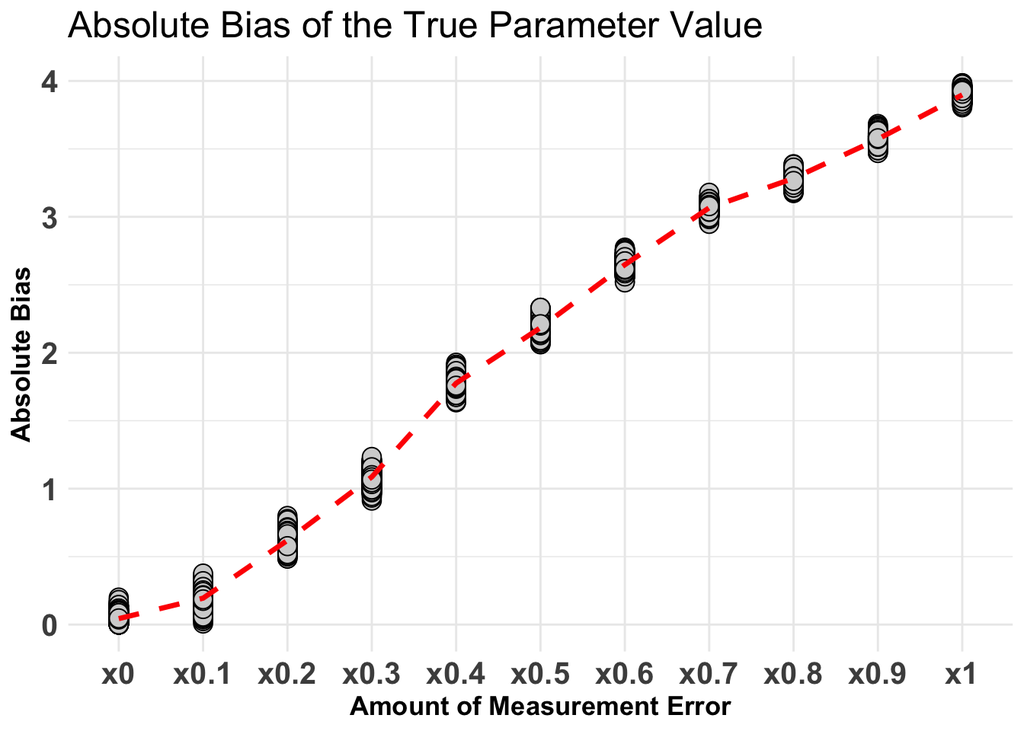

```r
absolute_error %>%
  pivot_longer(cols = everything()) %>%
  ggplot(aes(x = name, y = value, group = 1)) +
  geom_point(shape = 21,
             size = 4,
             color = "black",
             fill = "light grey") +
  stat_summary(fun = mean,
               geom = "line",
               color = "red",
               size = 1.2,
               linetype = "dashed") +
  labs(x = "Amount of Measurement Error",
       y = "Absolute Bias",
       title = "Absolute Bias of the True Parameter Value")
```

Notice that as the amount of measurement increases so too does the absolute bias of the model coefficient.